# CEFE Social Networks Course: Session 4

Matthew Silk

2023-04-13

### Set up R environment

First we need to load the R packages we will use. You may need to install these if you haven’t used them before using the `install.packages()` command in R. For genNetDem you will need to follow the instructions [here](https://github.com/NETDEM-project/genNetDem) to install it.

```r
set.seed(1)

library(igraph)
library(asnipe)
library(viridis)
library(assortnet)
library(genNetDem)
library(sna)
library(STRAND)
library(cmdstanr)
library(sbm)
library(ergm)
library(ergm.count)
library(tnet)
```

## SESSION 4: PART 2

[Stochastic block models (**SBMs**)](https://skewed.de/tiago/blog/inference-compression) are a generative model for networks that can be used a statistical tool to model group or community structure in networks. They can be used to identify any groups of nodes in a network that share similar patterns of sociality, so in addition to their traditional use to detect community structure, they can also be applied to detect assortative mixing (*think of our colour example from the last session*), disassortative mixing (*when red is more likely to interact with orange and vice versa*) and core-periphery structure among other network features. However, for now we fill focus on how they can be used to detect network communities as this is a common challenge in animal social and movement networks.

Let’s start with our `full_adj` network again and add some edge weights as we have before. We can then fit a simple SBM using the R packages STRAND and [sbm](https://cran.r-project.org/web/packages/sbm/index.html).

```r
#Read in the network object
full_adj<-readRDS("full_adj.RDS")
#Read in associated trait data
ind_data<-readRDS("ind_data.RDS")
names(ind_data)[1]<-"id"

#Create a weighted version of full_adj - we are adding edge weights from a poisson distribution this time
full_adj_weight<-rpois(sum(upper.tri(full_adj)),4)
full_adj[upper.tri(full_adj)]<-full_adj_weight*full_adj[upper.tri(full_adj)]
full_adj[lower.tri(full_adj)]<-t(full_adj)[lower.tri(full_adj)]

#Create igraph network object
network<-igraph::graph_from_adjacency_matrix(full_adj,mode="undirected",weighted=TRUE)
igraph::V(network)$size<-5+ind_data$offspring
igraph::V(network)$sex<-ind_data$sex
igraph::V(network)$group<-ind_data$group
```

The advantage of **STRAND** is that it is easy to combine stohastic block models with other types of network model that incorporate features of nodal and dyadic regressions - in fact you can specify separate models for focal (the iniator of edges), target (the receiver of edges) and dyad (the combined effect of the dyad) just as you would in the social relations model that was introduced at the end of the last session. However, a big disadvantage of **STRAND** is that you have to pre-specify the group you are interested in, making it less useful for finding communities without extensive model comparisons (although this is promised as a tool for future developments). **STRAND** is therefore better for testing patterns of assortativity of diassortativity between known groups (as we have in our example network) or traits (e.g. sex).

For this purpose of finding communities in the network, using the **sbm** package is better as it does not rely on pre-specified groups. You will see when you run the code that it automatically compares models for different numbers of groups for you to find the best fit to your dataset.

Before working with STRAND you may need to install `cmdstan` and run `cmdstanr::check_cmdstan_toolchain(fix=TRUE)`. Otherwise you will get errors when fitting models. Even then you may still have issues. If this is the case then look at how the model works, but spend more time working with the code for the sbm package and trying out some of the challenges below.

- Fiting an SBM with STRAND

```r
#Create groups data
groups<-data.frame(as.factor(ind_data$group))
names(groups)<-"groups"

#Format data for STRAND
model_dat<-make_strand_data(self_report=list(full_adj),
                            block_covariates = groups,
                            individual_covariates=NULL,
                            dyadic_covariates=NULL,
                            outcome_mode = "poisson")

set_cmdstan_path("C:/Users/matth/Documents/cmdstan-2.31.0")

#Fit model
sbm1<-STRAND::fit_block_model(data=model_dat,
                              block_regression=~groups,
                              focal_regression=~1,
                              target_regression=~1,
                              dyad_regression=~1,
                              mode="mcmc",
                              stan_mcmc_parameters = list(seed = 1, chains = 1,parallel_chains = 1,
                                                          refresh = 100, iter_warmup = 100, iter_sampling = 100,
                                                          max_treedepth = NULL, adapt_delta = NULL))

#Model summary - be warned this is a really complicated object
res_sbm1<-summarize_strand_results(sbm1)

#This is the most important part to look at for us
res_sbm1$summary
```

- Fitting an SBM with sbm package

```r
#Add rownames and colnames to matrix
rownames(full_adj)<-colnames(full_adj)<-seq(1,100,1)

#Code to estimate the stochatic block model (without covariates)
sbm2<-estimateSimpleSBM(full_adj,model ="poisson",directed=FALSE,dimLabels="ID",estimOptions=list(plot=FALSE))
```

[output not shown]

[output cut: 87 more lines]

```
##         -> For 15 groups
##     -> With descending number of groups
##         -> For 14 groups
##         -> For 13 groups
##         -> For 12 groups
##         -> For 11 groups
##         -> For 10 groups
##         -> For 9 groups
##         -> For 8 groups
##         -> For 7 groups
##         -> For 6 groups
##         -> For 5 groups
##         -> For 4 groups
##         -> For 3 groups
##         -> For 2 groups
```

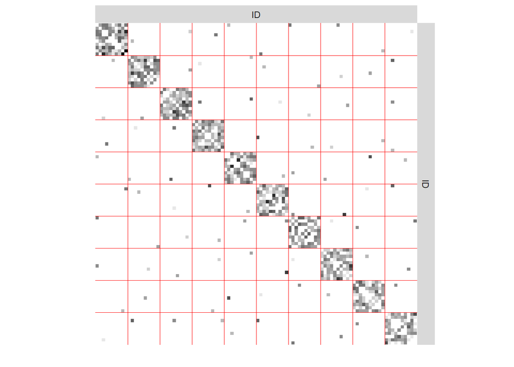

```r
#We can then plot our block structure compared to the social network
plot(sbm2)
```

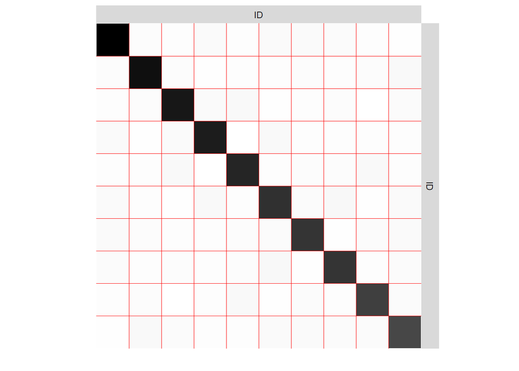

```r
plot(sbm2,type="expected")
```

```r
#We can extract information on the number of blocks
sbm2$nbBlocks
```

```
## [1] 10
```

```r
#We can also show which individuals are in which blocks either in summarised form
sbm2$memberships
```

```
##   [1]  7  7  7  7  7  7  7  7  7  7  5  5  5  5  5  5  5  5  5  5  6  6  6  6  6
##  [26]  6  6  6  6  6  1  1  1  1  1  1  1  1  1  1 10 10 10 10 10 10 10 10 10 10
##  [51]  9  9  9  9  9  9  9  9  9  9  3  3  3  3  3  3  3  3  3  3  2  2  2  2  2
##  [76]  2  2  2  2  2  4  4  4  4  4  4  4  4  4  4  8  8  8  8  8  8  8  8  8  8
```

```r
#or in matrix form
sbm2$indMemberships
```

```
##        [,1] [,2] [,3] [,4] [,5] [,6] [,7] [,8] [,9] [,10]
##   [1,]    0    0    0    0    0    0    1    0    0     0
##   [2,]    0    0    0    0    0    0    1    0    0     0
##   [3,]    0    0    0    0    0    0    1    0    0     0
##   [4,]    0    0    0    0    0    0    1    0    0     0
##   [5,]    0    0    0    0    0    0    1    0    0     0
##   [6,]    0    0    0    0    0    0    1    0    0     0
##   [7,]    0    0    0    0    0    0    1    0    0     0
##   [8,]    0    0    0    0    0    0    1    0    0     0
##   [9,]    0    0    0    0    0    0    1    0    0     0
##  [10,]    0    0    0    0    0    0    1    0    0     0
##  [11,]    0    0    0    0    1    0    0    0    0     0
##  [12,]    0    0    0    0    1    0    0    0    0     0
##  [13,]    0    0    0    0    1    0    0    0    0     0
##  [14,]    0    0    0    0    1    0    0    0    0     0
```

[output cut: 86 more lines]

```r
#We can also show the proportion of the network in each block
sbm2$blockProp
```

```
##  [1] 0.1 0.1 0.1 0.1 0.1 0.1 0.1 0.1 0.1 0.1
```

```r
#The parameters influencing connection strength between members of the different blocks
sbm2$connectParam
```

```
## $mean
##             [,1]       [,2]        [,3]        [,4]        [,5]       [,6]
##  [1,] 3.61696382 0.03647864 0.026556248 0.065705507 0.036183920 0.06549920
##  [2,] 0.03647864 3.46438771 0.045988427 0.016506137 0.036007085 0.03590884
##  [3,] 0.02655625 0.04598843 3.333682884 0.065410783 0.075107224 0.01618194
##  [4,] 0.06570551 0.01650614 0.065410783 3.246568114 0.006406905 0.08474472
##  [5,] 0.03618392 0.03600709 0.075107224 0.006406905 3.094144498 0.03561412
##  [6,] 0.06549920 0.03590884 0.016181939 0.084744721 0.035614119 2.89826153
##  [7,] 0.06537149 0.04558564 0.025858733 0.035594471 0.045290912 0.05499718
##  [8,] 0.05555715 0.02596680 0.045457923 0.025780139 0.045281088 0.09420538
##  [9,] 0.03576148 0.04538915 0.006053235 0.035397988 0.084312458 0.01558267
## [10,] 0.01613282 0.07478303 0.055056123 0.035378339 0.035270274 0.07439006
##             [,7]       [,8]        [,9]      [,10]
##  [1,] 0.06537149 0.05555715 0.035761481 0.01613282
##  [2,] 0.04558564 0.02596680 0.045389154 0.07478303
##  [3,] 0.02585873 0.04545792 0.006053235 0.05505612
##  [4,] 0.03559447 0.02578014 0.035397988 0.03537834
##  [5,] 0.04529091 0.04528109 0.084312458 0.03527027
##  [6,] 0.05499718 0.09420538 0.015582666 0.07439006
##  [7,] 2.83275662 0.01564161 0.054672981 0.06445784
##  [8,] 0.01564161 2.83273484 0.035054142 0.05464351
##  [9,] 0.05467298 0.03505414 2.658396377 0.05445685
## [10,] 0.06445784 0.05464351 0.054456849 2.52790939
```

```r
#And using these, model predictions of the edge strengths for the whole network (here for the first 20 individuals only for space reasons).
sbm2$expectation[1:20,1:20]
```

[output not shown]

[output cut: 48 more lines]

Using what you know about the structure of the network from previous sessions, see if you are happy with how well the model has fitted the data. Perhaps think about what the model plot would like for the other types of networks we have worked with in previous sessions.

Using the model object we can also compare how well the network structure is explained with different numbers of blocks - this could be useful if we wanted to check whether there were explanations with similar power to explain our network structure.

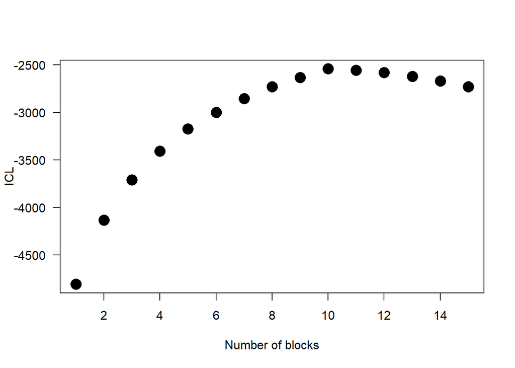

```r
alt_models<-sbm2$storedModels

#ICL means integrated compete-data likelihood
plot(alt_models$ICL~alt_models$nbBlocks,pch=16,cex=2,las=1,ylab="ICL",xlab="Number of blocks")
```

Another feature that might be useful is that we can look at the probability of an individual being in the community that it is assigned to. Here we look at it only for the first 30 individuals, but feel free to look further through this dataframe.

```r
sbm2$probMemberships[1:30,]
```

```
##               [,1]         [,2]         [,3]         [,4]         [,5]
##  [1,] 0.0009920635 0.0009920635 0.0009920635 0.0009920635 0.0009920635
##  [2,] 0.0009920635 0.0009920635 0.0009920635 0.0009920635 0.0009920635
##  [3,] 0.0009920635 0.0009920635 0.0009920635 0.0009920635 0.0009920635
##  [4,] 0.0009920635 0.0009920635 0.0009920635 0.0009920635 0.0009920635
##  [5,] 0.0009920635 0.0009920635 0.0009920635 0.0009920635 0.0009920635
##  [6,] 0.0009920635 0.0009920635 0.0009920635 0.0009920635 0.0009920635
##  [7,] 0.0009920635 0.0009920635 0.0009920635 0.0009920635 0.0009920635
##  [8,] 0.0009920635 0.0009920635 0.0009920635 0.0009920635 0.0009920635
##  [9,] 0.0009920635 0.0009920635 0.0009920635 0.0009920635 0.0009920635
## [10,] 0.0009920635 0.0009920635 0.0009920635 0.0009920635 0.0009920635
## [11,] 0.0009920635 0.0009920635 0.0009920635 0.0009920635 0.9910714286
## [12,] 0.0009920635 0.0009920635 0.0009920635 0.0009920635 0.9910714286
## [13,] 0.0009920635 0.0009920635 0.0009920635 0.0009920635 0.9910714286
## [14,] 0.0009920635 0.0009920635 0.0009920635 0.0009920635 0.9910714286
```

[output cut: 47 more lines]

You can also use SBMs to generate networks, or in STRAND use a combination of the SBMs and the social relations model. Here is a quick demonstration of using **STRAND** to simulate from an SBM

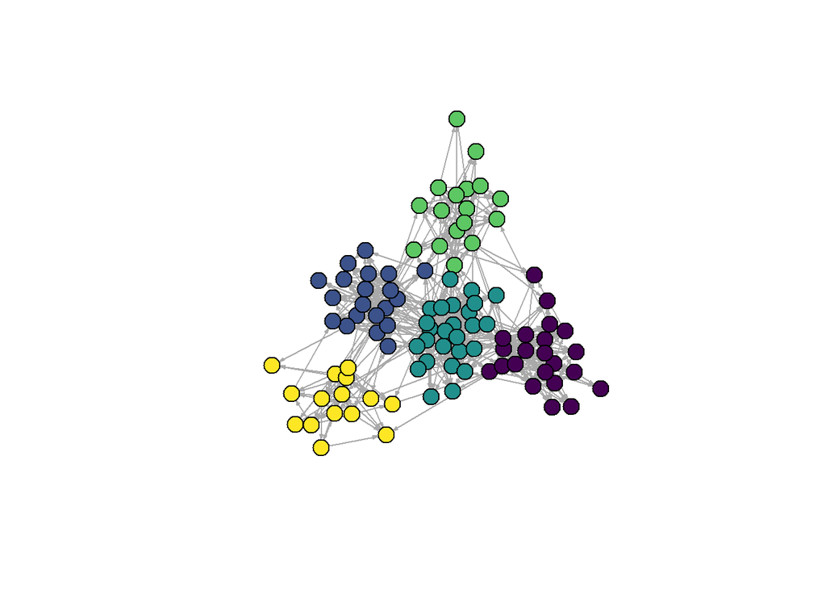

```r
#I've adapted this code directly from the help page of the package

#One type of group
V<-1
#Five groups
G<-5
#Number of individuals
N_id<-100

#Put individuals in groups
group<-sample(1:5,N_id,replace=TRUE)
#Parameters for between and within group social interactions
B<-matrix(-6, nrow=G, ncol=G)
diag(B)<- -1.5
B[1,3] = -5
B[3,2] = -4

#Simulate the network
sbm_adj<-simulate_sbm_network(N_id=N_id, B=list(B=B), V=V, groups=data.frame(clique=factor(group)),
                         individual_predictor=matrix(rnorm(N_id,0,1), nrow=N_id, ncol=1),
                         individual_effects=matrix(c(1.7, 0.3),ncol=1, nrow=2),
                         mode="bernoulli")

#Convert into igraph object and plot
sbm_net<-graph_from_adjacency_matrix(sbm_adj$network, mode = c("directed"))
cols<-viridis(5)
V(sbm_net)$color = cols[sbm_adj$group_ids$clique]
plot(sbm_net,vertex.label=NA,vertex.size=10,edge.arrow.size=0.2)
```

```r
#Note that the objects produced by the STRAND simulation algorithm contain lots of additional information about the individuals and dyads
str(sbm_adj)
```

```
## List of 8
##  $ network              : num [1:100, 1:100] 0 0 0 0 0 0 0 0 0 0 ...
##  $ tie_strength         : num [1:100, 1:100] 0.00 8.04e-05 9.97e-03 5.37e-02 5.72e-02 ...
##  $ group_ids            :'data.frame':   100 obs. of  1 variable:
##   ..$ clique: Factor w/ 5 levels "1","2","3","4",..: 2 5 4 3 3 4 3 2 2 3 ...
##  $ individual_predictors: num [1:100, 1] -0.277 -1.968 0.873 0.714 0.753 ...
##  $ dyadic_predictors    : NULL
##  $ sr                   : num [1:100, 1:2] -0.47 -3.35 1.48 1.21 1.28 ...
##  $ dr                   : num [1:100, 1:100] 0 -6 -6 -4 -4 -6 -4 -1.5 -1.5 -4 ...
##  $ samps                : int [1:100, 1:100] 23 17 15 14 11 12 13 14 16 16 ...
```

We can see that gives 1) the network; 2) the expected tie strength; 3) the groups for each individual; 4) the individual predictors simulated for each individual; 5) the dyadic predictors, and then further less useful information.

Note also that **STRAND** simulates directed networks by default. If you want to simulate undirected networks with community structure you could symmetrise the networks produced by **STRAND** by taking the aggregate, maximum, mean or minimum value of the dyad, or use another package.

For example, for simpler models, **sbm** also has the functionality to simulate networks with a block structure

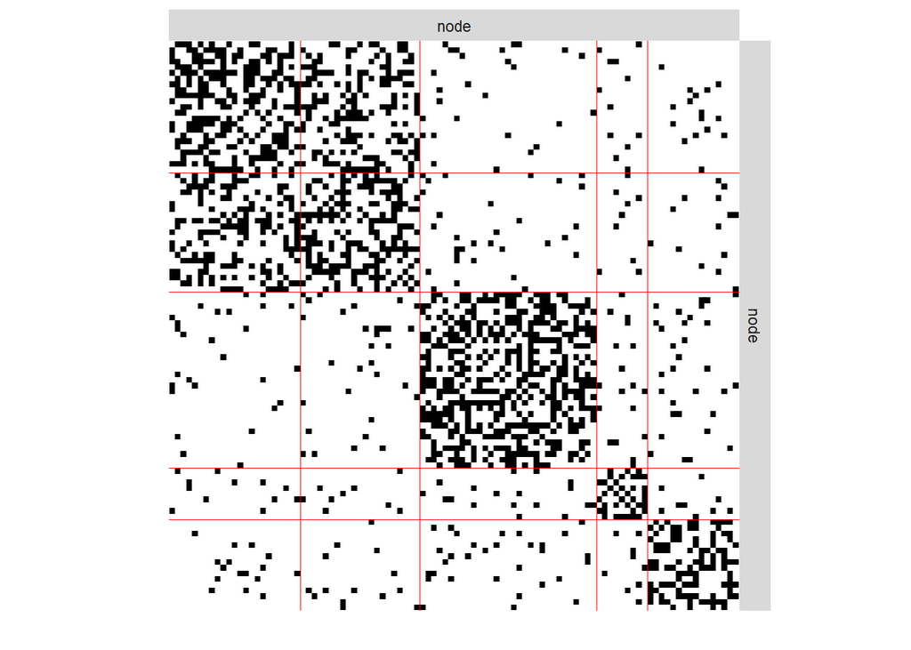

```r
N_id<-100
#Group proportions - note we make groups of different sizes here
blockProp <- c(0.25,0.25,0.25,0.1,0.15)
#Connectivity matrix - raw probabilities this time
means<-diag(.4, 5) + 0.05
means[1,2]<-means[2,1]<-0.35
connectParam<-list(mean=means)
#Generate network
mySampler<-sampleSimpleSBM(N_id,blockProp,connectParam,model='bernoulli')
#Plot block structure using sbm functionality
plot(mySampler)
```

```r
#Generate adjacency matrix
sbm_adj2<-mySampler$networkData
```

Another complementary option is my package genNetDem that we used briefly yesterday can also simulate networks with community structure.

##SESSION 4: PART 3

Exponential random graph models (**ERGMS**) are one of the most widely used tools in social network analysis in sociology, but have also been used a little [to study animal social networks](https://doi.org/10.1016/j.anbehav.2017.08.005) and recently also applied to [movement networks](https://movementecologyjournal.biomedcentral.com/articles/10.1186/s40462-023-00380-7).

They are very powerful tools for studying well-sampled network data, especially behavioural interactions in groups. They are particularly useful for situations where you may want to mix nodal and dyadic explanatory variables, or to study social processes such as transitive closure or reciprocity. We will use some of the networks created above and in previous sessions to run through the basics of fitting ERGMs.

The best developed packages for fitting ERGMs fall within the [network](https://cran.r-project.org/web/packages/network/index.html) suite of packages. Unfortunately for us this means learning a few new basic network-handling commands in R which are similar but not the same to igraph…

```r
rownames(sbm_adj2)<-colnames(sbm_adj2)<-seq(1,100,1)
diag(sbm_adj2)<-0
sa2.edgelist<-as.tnet(sbm_adj2)
sa2<-network(sa2.edgelist[,1:2],directed=FALSE)

#Use and create some individual/nodal variables
groups<-mySampler$memberships
sex<-sample(c("M","F"),100,replace=TRUE)
size<-rnorm(100)

#Set some node attributes
network::set.vertex.attribute(sa2,"group",groups)
network::set.vertex.attribute(sa2,"sex",sex)
network::set.vertex.attribute(sa2,"size",size)
```

Once we have the data set-up then fitting a basic ERGM is relatively simple using the ergm package - we will start with a binary, undirected network - from sbm_adj2. You can read more about the types of terms that can be fitted in ERGMs [here](https://cran.r-project.org/web/packages/ergm/vignettes/ergm-term-crossRef.html). There are a lot! Don’t be put-off we will go over many of the main ones here.

One crucial point is that in ERGMs for binary networks including the `edges` or `density` term is important as it operate somewhat like an intercept in a linear model and makes interpreting other terms much easier.

```r
#Let's start then with just the intercept only model
#We fit it like this
ergm0<-ergm(sa2~edges)
```

```
## Starting maximum pseudolikelihood estimation (MPLE):
```

```
## Evaluating the predictor and response matrix.
```

```
## Maximizing the pseudolikelihood.
```

```
## Finished MPLE.
```

```
## Stopping at the initial estimate.
```

```
## Evaluating log-likelihood at the estimate.
```

```r
#And can look at the model summary like this
summary(ergm0)
```

```
## Call:
## ergm(formula = sa2 ~ edges)
##
## Maximum Likelihood Results:
##
##       Estimate Std. Error MCMC % z value Pr(>|z|)
## edges -1.59496    0.03796      0  -42.02   <1e-04 ***
## ---
## Signif. codes:  0 '***' 0.001 '**' 0.01 '*' 0.05 '.' 0.1 ' ' 1
##
##      Null Deviance: 6862  on 4950  degrees of freedom
##  Residual Deviance: 4493  on 4949  degrees of freedom
##
## AIC: 4495  BIC: 4501  (Smaller is better. MC Std. Err. = 0)
```

```r
#We can use inbuilt commands in the ERGM package to look at model goodness-of-fit
gof(ergm0)
```

```
##
## Goodness-of-fit for degree
##
##          obs min  mean max MC p-value
## degree5    0   0  0.02   1       1.00
## degree6    2   0  0.07   1       0.00
## degree7    0   0  0.24   2       1.00
## degree8    4   0  0.61   3       0.00
## degree9    4   0  1.02   4       0.10
## degree10   1   0  2.13   6       0.72
## degree11   3   0  3.46  10       1.00
## degree12   5   0  5.04  12       1.00
## degree13  11   1  6.66  12       0.18
## degree14   4   3  8.49  16       0.10
## degree15   3   3 10.15  19       0.02
## degree16   9   4 10.48  18       0.82
## degree17   6   1 10.09  18       0.20
## degree18   4   4 10.36  17       0.02
## degree19  12   3  8.45  17       0.32
## degree20   7   2  6.90  14       1.00
## degree21  12   1  5.52  11       0.00
## degree22   5   0  3.90   9       0.78
## degree23   3   0  2.48   6       0.96
## degree24   2   0  1.53   6       0.84
## degree25   1   0  1.19   4       1.00
## degree26   1   0  0.65   3       0.98
## degree27   1   0  0.34   3       0.56
## degree28   0   0  0.14   1       1.00
## degree29   0   0  0.04   1       1.00
## degree30   0   0  0.02   1       1.00
## degree31   0   0  0.01   1       1.00
## degree33   0   0  0.01   1       1.00
##
## Goodness-of-fit for edgewise shared partner
##
##       obs min   mean max MC p-value
## esp0   59  29  50.10  82       0.28
## esp1   72 110 140.69 171       0.00
## esp2   64 167 200.36 245       0.00
## esp3   64 149 189.79 228       0.00
```

[output cut: 8 more lines]

```
## esp12   8   0   0.04   1       0.00
## esp13   3   0   0.00   0       0.00
## esp14   1   0   0.00   0       0.00
##
## Goodness-of-fit for minimum geodesic distance
##
##    obs  min    mean  max MC p-value
## 1  835  781  837.83  893       0.96
## 2 3250 3816 3872.29 3932       0.00
## 3  865  143  239.88  329       0.00
##
## Goodness-of-fit for model statistics
##
##        obs        min       mean        max MC p-value
##     835.00     781.00     837.83     893.00       0.96
```

These goodness-of-fit tests cover the basics, and we may want to design further tests of our own to tests other aspects of network structure but it is a good start. For each of these outputs it gives us the observed values for different network statistics as well as information on the `min`, `mean` and `max` from the model outputs. We want these two-tailed p values to be non-significant really.

As you can see our intercept only model does a terrible job for pretty much all os the different outputs here!

Therefore we may need to make our model more complex, the obvious starting point is by including the fact that individuals are assorted within groups - for this we use the `nodematch` term - look this up in the help pages to learn more.

```r
ergm1<-ergm(sa2~edges+nodematch("group"))
```

```
## Starting maximum pseudolikelihood estimation (MPLE):
```

```
## Evaluating the predictor and response matrix.
```

```
## Maximizing the pseudolikelihood.
```

```
## Finished MPLE.
```

```
## Stopping at the initial estimate.
```

```
## Evaluating log-likelihood at the estimate.
```

```r
summary(ergm1)
```

```
## Call:
## ergm(formula = sa2 ~ edges + nodematch("group"))
##
## Maximum Likelihood Results:
##
##                 Estimate Std. Error MCMC % z value Pr(>|z|)
## edges           -2.37166    0.05756      0  -41.20   <1e-04 ***
## nodematch.group  2.23491    0.08379      0   26.67   <1e-04 ***
## ---
## Signif. codes:  0 '***' 0.001 '**' 0.01 '*' 0.05 '.' 0.1 ' ' 1
##
##      Null Deviance: 6862  on 4950  degrees of freedom
##  Residual Deviance: 3753  on 4948  degrees of freedom
##
## AIC: 3757  BIC: 3770  (Smaller is better. MC Std. Err. = 0)
```

```r
gof(ergm1)
```

```
##
## Goodness-of-fit for degree
##
##          obs min mean max MC p-value
## degree4    0   0 0.06   1       1.00
## degree5    0   0 0.13   2       1.00
## degree6    2   0 0.33   2       0.10
## degree7    0   0 0.70   3       0.90
## degree8    4   0 1.18   6       0.10
## degree9    4   0 1.89   5       0.20
## degree10   1   0 3.08   9       0.30
## degree11   3   0 4.40  12       0.84
## degree12   5   0 5.39  13       1.00
## degree13  11   1 6.60  13       0.12
## degree14   4   2 7.27  12       0.20
## degree15   3   3 8.84  18       0.02
## degree16   9   3 9.27  15       1.00
## degree17   6   2 9.02  17       0.46
## degree18   4   3 8.37  16       0.22
## degree19  12   2 7.43  16       0.20
## degree20   7   1 6.38  15       0.80
## degree21  12   0 5.65  20       0.02
## degree22   5   0 4.50  10       1.00
## degree23   3   0 3.10   9       1.00
## degree24   2   0 2.47   7       1.00
## degree25   1   0 1.44   5       1.00
## degree26   1   0 0.84   5       1.00
## degree27   1   0 0.82   2       1.00
## degree28   0   0 0.43   2       1.00
## degree29   0   0 0.19   1       1.00
## degree30   0   0 0.16   1       1.00
## degree31   0   0 0.05   1       1.00
## degree32   0   0 0.01   1       1.00
##
## Goodness-of-fit for edgewise shared partner
##
##       obs min   mean max MC p-value
## esp0   59  18  44.67  62       0.10
## esp1   72  62 100.52 133       0.02
## esp2   64  93 125.41 159       0.00
```

[output cut: 12 more lines]

```
## esp15   0   0   0.22   4       1.00
## esp16   0   0   0.05   1       1.00
##
## Goodness-of-fit for minimum geodesic distance
##
##    obs  min    mean  max MC p-value
## 1  835  770  835.90  892       0.98
## 2 3250 3493 3663.64 3795       0.00
## 3  865  289  450.46  687       0.00
##
## Goodness-of-fit for model statistics
##
##                 obs min  mean max MC p-value
## edges           835 770 835.9 892       0.98
## nodematch.group 505 475 505.4 543       0.84
```

Things have improved but perhaps not as much as we’d hoped. Often in ERGMs we can make individual terms more advanced by adjusting arguments within them, for example here we let the model estimate a different assortativity value for different groups.

```r
ergm2<-ergm(sa2~edges+nodematch("group",diff=TRUE))
```

```
## Starting maximum pseudolikelihood estimation (MPLE):
```

```
## Evaluating the predictor and response matrix.
```

```
## Maximizing the pseudolikelihood.
```

```
## Finished MPLE.
```

```
## Stopping at the initial estimate.
```

```
## Evaluating log-likelihood at the estimate.
```

```r
summary(ergm2)
```

```
## Call:
## ergm(formula = sa2 ~ edges + nodematch("group", diff = TRUE))
##
## Maximum Likelihood Results:
##
##                   Estimate Std. Error MCMC % z value Pr(>|z|)
## edges             -2.37166    0.05756      0 -41.204   <1e-04 ***
## nodematch.group.1  2.26880    0.13844      0  16.389   <1e-04 ***
## nodematch.group.2  2.08398    0.15086      0  13.814   <1e-04 ***
## nodematch.group.3  2.28989    0.10922      0  20.965   <1e-04 ***
## nodematch.group.4  2.48288    0.33877      0   7.329   <1e-04 ***
## nodematch.group.5  2.13726    0.19263      0  11.095   <1e-04 ***
## ---
## Signif. codes:  0 '***' 0.001 '**' 0.01 '*' 0.05 '.' 0.1 ' ' 1
##
##      Null Deviance: 6862  on 4950  degrees of freedom
##  Residual Deviance: 3750  on 4944  degrees of freedom
##
## AIC: 3762  BIC: 3801  (Smaller is better. MC Std. Err. = 0)
```

```r
gof(ergm2)
```

```
##
## Goodness-of-fit for degree
##
##          obs min mean max MC p-value
## degree4    0   0 0.05   1       1.00
## degree5    0   0 0.15   2       1.00
## degree6    2   0 0.33   2       0.12
## degree7    0   0 0.70   4       0.98
## degree8    4   0 1.38   5       0.04
## degree9    4   0 2.26   7       0.36
## degree10   1   0 3.11   8       0.36
## degree11   3   1 4.40  10       0.64
## degree12   5   2 5.95  12       1.00
## degree13  11   3 6.64  14       0.12
## degree14   4   0 7.84  21       0.16
## degree15   3   1 8.70  19       0.14
## degree16   9   3 8.84  18       1.00
## degree17   6   3 8.67  18       0.36
## degree18   4   1 7.86  13       0.14
## degree19  12   3 7.36  14       0.10
## degree20   7   2 6.29  11       0.86
## degree21  12   0 5.03  13       0.02
## degree22   5   1 4.28   9       0.88
## degree23   3   0 3.46   9       1.00
## degree24   2   0 2.10   8       1.00
## degree25   1   0 1.89   5       0.78
## degree26   1   0 1.35   5       1.00
## degree27   1   0 0.66   4       0.98
## degree28   0   0 0.35   2       1.00
## degree29   0   0 0.22   2       1.00
## degree30   0   0 0.06   1       1.00
## degree31   0   0 0.03   1       1.00
## degree33   0   0 0.03   1       1.00
## degree34   0   0 0.01   1       1.00
##
## Goodness-of-fit for edgewise shared partner
##
##       obs min   mean max MC p-value
## esp0   59  32  46.77  67       0.14
## esp1   72  67 102.88 129       0.02
```

[output cut: 19 more lines]

```
##    obs  min    mean  max MC p-value
## 1  835  785  831.41  883          1
## 2 3250 3539 3659.49 3773          0
## 3  865  306  459.08  618          0
## 4    0    0    0.02    2          1
##
## Goodness-of-fit for model statistics
##
##                   obs min   mean max MC p-value
## edges             835 785 831.41 883       1.00
## nodematch.group.1 120  93 116.07 134       0.80
## nodematch.group.2  90  78  91.34 104       0.86
## nodematch.group.3 223 204 225.65 247       0.76
## nodematch.group.4  19  10  17.49  23       0.76
## nodematch.group.5  53  42  54.01  67       0.98
```

We are still not doing a great job of explaining key aspects of our network structure, expecially the edgewise shared partners. But before you try and improve the model fit further, wwe’ll first introduce more of the basic terms for binary, undirected ERGMs

```r
#We can include multiple explanatory variables easily
ergm3<-ergm(sa2~edges+nodematch("group",diff=TRUE)+nodematch("sex"))
```

```
## Starting maximum pseudolikelihood estimation (MPLE):
```

```
## Evaluating the predictor and response matrix.
```

```
## Maximizing the pseudolikelihood.
```

```
## Finished MPLE.
```

```
## Stopping at the initial estimate.
```

```
## Evaluating log-likelihood at the estimate.
```

```r
#For factors we can include the `nodefactor` terms to test for differences in connectivity between levels
ergm4<-ergm(sa2~edges+nodematch("group",diff=TRUE)+nodematch("sex")+nodefactor("sex"))
```

```
## Starting maximum pseudolikelihood estimation (MPLE):
## Evaluating the predictor and response matrix.
## Maximizing the pseudolikelihood.
## Finished MPLE.
## Stopping at the initial estimate.
## Evaluating log-likelihood at the estimate.
```

```r
#The equivalent for continuous covariates is the `nodecov` term
ergm5<-ergm(sa2~edges+nodematch("group",diff=TRUE)+nodematch("sex")+nodefactor("sex")+nodecov("size"))
```

```
## Starting maximum pseudolikelihood estimation (MPLE):
## Evaluating the predictor and response matrix.
## Maximizing the pseudolikelihood.
## Finished MPLE.
## Stopping at the initial estimate.
## Evaluating log-likelihood at the estimate.
```

```r
#While absdiff let's us test the importance of similarity between continuous node traits on the probability of an edge
ergm6<-ergm(sa2~edges+nodematch("group",diff=TRUE)+nodematch("sex")+nodefactor("sex")+nodecov("size")+absdiff("size"))
```

```
## Starting maximum pseudolikelihood estimation (MPLE):
## Evaluating the predictor and response matrix.
## Maximizing the pseudolikelihood.
## Finished MPLE.
## Stopping at the initial estimate.
## Evaluating log-likelihood at the estimate.
```

We may want to add in more structural terms - here use triangles which estimates such as the number of triangles compared with a random network. The code below shows this but I haven’t run it as the models take a long time to fit

```
ergm7<-ergm(sa2~edges+triangles+nodematch("group"))

#We can also make these structural terms more complex by assessing how they vary according to attributes
ergm8<-ergm(sa2~edges+triangle(attr="group",diff=TRUE)+nodematch("group",diff=TRUE)+nodematch("sex")+nodefactor("sex")+nodecov("size")+absdiff("size"))
```

Feel free to try more different terms to get a feel for how ERGMs work. You will see that in the model summary we have a lot of the information we are used to for the assessment of model fit (e.g. AIC) as well as the importance of individual variables in the model. We won’t go into details of inference here.

One difference between ERGMs and the types of statistical modelling you are probably more used to is that it is frequently encouraged to fit a “basic” version of your ERGM that includes the structural terms you think are important in your network before adding variables related to your hypotheses of interest (e.g. node traits or edge traits). In part this is simply a difference between fields, but it is also related to the fact that ERGMs with structural terms can at times be difficult to fit (often with problems with MCMC convergence).

At a more advanced levels there is also plenty of advice online related to refining the sampling to improve model convergence and parameter estimation, but won’t go into that here.

Instead we will briefly introduce fitting ERGMs to directed and weighted networks. After that you will have a lot of the tools to start fitting ERGMs and testing them a little more.

First directed networks…

```r
dir_mat<-readRDS("dir_mat.RDS")
ind_data<-readRDS("ind_data2.RDS")

#Create a binary version with only strong interactions included
dir_mat[which(dir_mat<3,arr.ind=TRUE)]<-0
dir_mat2<-sign(dir_mat)

#Create network object
rownames(dir_mat2)<-colnames(dir_mat2)<-seq(1,40,1)
diag(dir_mat2)<-0
dir.edgelist<-as.tnet(dir_mat2)
dir<-network(dir.edgelist[,1:2],directed=TRUE)

#Set node attributes
network::set.vertex.attribute(dir,"size",ind_data$size2)

#Fit a model with just intercept and size
dir1<-ergm(dir~edges+nodecov("size"))
```

```
## Starting maximum pseudolikelihood estimation (MPLE):
```

```
## Evaluating the predictor and response matrix.
```

```
## Maximizing the pseudolikelihood.
```

```
## Finished MPLE.
```

```
## Stopping at the initial estimate.
```

```
## Evaluating log-likelihood at the estimate.
```

```r
summary(dir1)
```

```
## Call:
## ergm(formula = dir ~ edges + nodecov("size"))
##
## Maximum Likelihood Results:
##
##              Estimate Std. Error MCMC % z value Pr(>|z|)
## edges        -1.65947    0.07203      0 -23.039   <1e-04 ***
## nodecov.size  0.34285    0.04300      0   7.972   <1e-04 ***
## ---
## Signif. codes:  0 '***' 0.001 '**' 0.01 '*' 0.05 '.' 0.1 ' ' 1
##
##      Null Deviance: 2163  on 1560  degrees of freedom
##  Residual Deviance: 1362  on 1558  degrees of freedom
##
## AIC: 1366  BIC: 1376  (Smaller is better. MC Std. Err. = 0)
```

```r
#But now with directed networks we can include new terms related to the direction of edges
#Such as the tendency for mutual connections
dir2<-ergm(dir~edges+nodecov("size")+mutual)
```

```
## Starting maximum pseudolikelihood estimation (MPLE):
## Evaluating the predictor and response matrix.
## Maximizing the pseudolikelihood.
## Finished MPLE.
## Starting Monte Carlo maximum likelihood estimation (MCMLE):
## Iteration 1 of at most 60:
```

```
## Optimizing with step length 1.0000.
## The log-likelihood improved by 0.0076.
## Convergence test p-value: < 0.0001. Converged with 99% confidence.
## Finished MCMLE.
## Evaluating log-likelihood at the estimate. Fitting the dyad-independent submodel...
## Bridging between the dyad-independent submodel and the full model...
## Setting up bridge sampling...
## Using 16 bridges: 1 2 3 4 5 6 7 8 9 10 11 12 13 14 15 16 .
## Bridging finished.
## This model was fit using MCMC.  To examine model diagnostics and check
## for degeneracy, use the mcmc.diagnostics() function.
```

```r
summary(dir2)
```

```
## Call:
## ergm(formula = dir ~ edges + nodecov("size") + mutual)
##
## Monte Carlo Maximum Likelihood Results:
##
##              Estimate Std. Error MCMC % z value Pr(>|z|)
## edges        -1.49123    0.07882      0 -18.920   <1e-04 ***
## nodecov.size  0.41405    0.05701      0   7.263   <1e-04 ***
## mutual       -1.40152    0.33947      0  -4.129   <1e-04 ***
## ---
## Signif. codes:  0 '***' 0.001 '**' 0.01 '*' 0.05 '.' 0.1 ' ' 1
##
##      Null Deviance: 2163  on 1560  degrees of freedom
##  Residual Deviance: 1341  on 1557  degrees of freedom
##
## AIC: 1347  BIC: 1364  (Smaller is better. MC Std. Err. = 0.5451)
```

```r
#We actually see that mutual edges are less likely than you'd expect by chance

#When we add these more complex structural terms, the ERGM starts using MCMC to fit the model. We can check model diagnostics like this
mcmc.diagnostics(dir2)
```

```
## Sample statistics summary:
##
## Iterations = 27648:524288
## Thinning interval = 1024
## Number of chains = 1
## Sample size per chain = 486
##
## 1. Empirical mean and standard deviation for each variable,
##    plus standard error of the mean:
##
##                 Mean     SD Naive SE Time-series SE
## edges        -0.4774 14.045   0.6371          0.716
## nodecov.size -1.7674 18.789   0.8523          0.854
## mutual        0.1296  3.285   0.1490          0.149
##
## 2. Quantiles for each variable:
##
##                2.5%    25%   50%   75% 97.5%
## edges        -27.88  -9.75 -1.00  9.00 28.00
## nodecov.size -39.11 -13.95 -2.03 11.08 34.01
## mutual        -6.00  -2.00  0.00  2.00  7.00
##
##
## Are sample statistics significantly different from observed?
##                 edges nodecov.size    mutual Overall (Chi^2)
## diff.      -0.4773663  -1.76736331 0.1296296              NA
## test stat. -0.6666816  -2.06962514 0.8698450       4.3303543
## P-val.      0.5049755   0.03848746 0.3843851       0.2319263
##
## Sample statistics cross-correlations:
##                  edges nodecov.size    mutual
## edges        1.0000000    0.2809995 0.3887959
## nodecov.size 0.2809995    1.0000000 0.3042983
## mutual       0.3887959    0.3042983 1.0000000
##
## Sample statistics auto-correlation:
## Chain 1
##               edges nodecov.size      mutual
## Lag 0    1.00000000   1.00000000  1.00000000
## Lag 1024 0.11524636   0.22392901  0.01702305
## Lag 2048 0.07064571   0.02427048  0.05263596
## Lag 3072 0.05701058  -0.09953921  0.07825527
## Lag 4096 0.02877397  -0.13778820 -0.03173057
## Lag 5120 0.03011512  -0.02706873 -0.06120163
##
## Sample statistics burn-in diagnostic (Geweke):
## Chain 1
##
## Fraction in 1st window = 0.1
## Fraction in 2nd window = 0.5
##
##        edges nodecov.size       mutual
##      -0.4404      -0.7604      -0.7024
##
## Individual P-values (lower = worse):
##        edges nodecov.size       mutual
##    0.6596137    0.4470439    0.4824248
## Joint P-value (lower = worse):  0.7998883 .
```

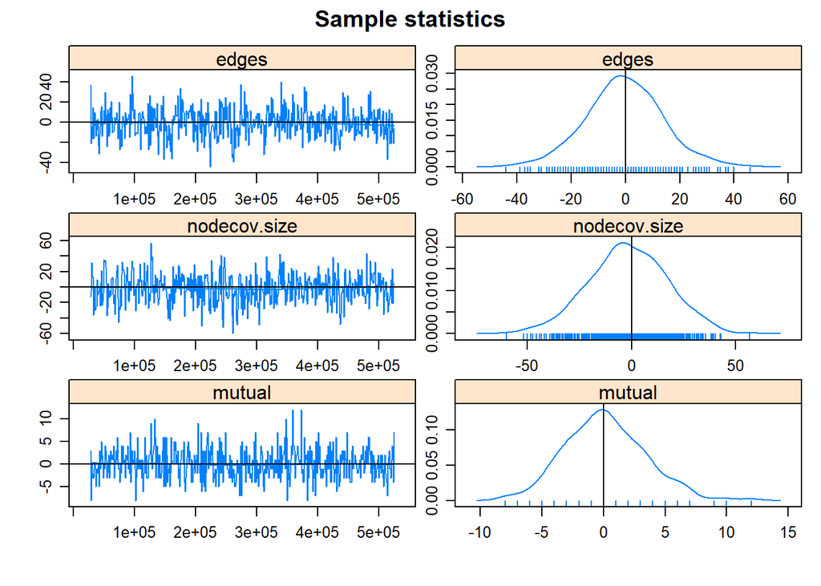

[output not shown]

```r
#They look OK here despite the relatively short Markov chain
```

And we can also include terms for transitive and cyclical triads. Again, the code below shows this but I haven’t run it as the models take a long time to fit.

```r
dir3<-ergm(dir~edges+mutual+ttriad+ctriad,silent=TRUE)
summary(dir3)
```

Feel free to explore more different combinations of parameters, but be prepared for long run times and issues with convergence, especially if you include lots of similar terms… This is part of the challenge of using ERGMs…

For weighted networks there are a reduced set of terms that can be included. Another addition is that ideally the intercept should now consist of both the `sum` term and `nonzero` term to deal with zero-inflation in the distribution of edge weights (this is almost inevitable in social networks which tend to be quite sparse).

The availability of different distributions for edge weights is also relatively limited, although is improving. We will stick to poisson models for edge weights here.

```r
#Reduce the weight of remaining edges by 2 so lowest count of interactions is 1
dir_mat3<-dir_mat
dir_mat3[which(dir_mat3>0,arr.ind=TRUE)]<-dir_mat3[which(dir_mat3>0,arr.ind=TRUE)]-2

#Create network object
rownames(dir_mat3)<-colnames(dir_mat3)<-seq(1,40,1)
diag(dir_mat3)<-0
dir.edgelist<-as.tnet(dir_mat3)
dirB<-network(dir.edgelist[,1:2],directed=TRUE)

#Set node attributes
network::set.vertex.attribute(dirB,"size",ind_data$size2)

#Set edge attributtes
network::set.edge.attribute(dirB,"weight",as.vector(dir.edgelist[,3]))


#Fit a model with just intercept and size
dirB1<-ergm(dirB~sum+nonzero+nodecov("size"),reference=~Poisson,response="weight")
```

```
## Starting contrastive divergence estimation via CD-MCMLE:
```

```
## Iteration 1 of at most 60:
```

```
## Convergence test P-value:2.1e-173
```

```
## The log-likelihood improved by 1.772.
```

```
## Iteration 2 of at most 60:
```

```
## Convergence test P-value:6.3e-120
```

```
## The log-likelihood improved by 1.37.
```

```
## Iteration 3 of at most 60:
```

```
## Convergence test P-value:3.3e-34
```

```
## The log-likelihood improved by 0.2626.
```

```
## Iteration 4 of at most 60:
```

```
## Convergence test P-value:1e-01
```

```
## The log-likelihood improved by 0.008141.
```

```
## Iteration 5 of at most 60:
```

```
## Convergence test P-value:1.5e-01
```

```
## The log-likelihood improved by 0.007036.
```

```
## Iteration 6 of at most 60:
```

```
## Convergence test P-value:1.7e-01
```

```
## The log-likelihood improved by 0.006692.
```

```
## Iteration 7 of at most 60:
```

```
## Convergence test P-value:8.5e-01
```

```
## Convergence detected. Stopping.
```

```
## The log-likelihood improved by 0.001029.
```

```
## Finished CD.
```

```
## Starting Monte Carlo maximum likelihood estimation (MCMLE):
```

```
## Iteration 1 of at most 60:
```

```
## Optimizing with step length 1.0000.
```

```
## The log-likelihood improved by 0.5289.
```

```
## Estimating equations are not within tolerance region.
```

```
## Iteration 2 of at most 60:
```

```
## Optimizing with step length 1.0000.
```

```
## The log-likelihood improved by 0.0620.
```

[output not shown]

```r
summary(dirB1)
```

```
## Call:
## ergm(formula = dirB ~ sum + nonzero + nodecov("size"), response = "weight",
##     reference = ~Poisson)
##
## Monte Carlo Maximum Likelihood Results:
##
##                  Estimate Std. Error MCMC % z value Pr(>|z|)
## sum              -0.07336    0.07827      0  -0.937    0.349
## nonzero          -2.11904    0.13604      0 -15.576   <1e-04 ***
## nodecov.sum.size  0.20546    0.02279      0   9.017   <1e-04 ***
## ---
## Signif. codes:  0 '***' 0.001 '**' 0.01 '*' 0.05 '.' 0.1 ' ' 1
##
##      Null Deviance:     0  on 1560  degrees of freedom
##  Residual Deviance: -1505  on 1557  degrees of freedom
##
## Note that the null model likelihood and deviance are defined to be 0.
## This means that all likelihood-based inference (LRT, Analysis of
## Deviance, AIC, BIC, etc.) is only valid between models with the same
## reference distribution and constraints.
##
## AIC: -1499  BIC: -1483  (Smaller is better. MC Std. Err. = 7.219)
```

```r
#But now with directed networks we can include new terms related to the direction of edges
#Such as the tendency for mutual connections
dirB2<-ergm(dirB~edges+nodecov("size")+mutual(form="nabsdiff"),reference=~Poisson,response="weight")
```

[output not shown]

```r
summary(dirB2)
```

```
## Call:
## ergm(formula = dirB ~ edges + nodecov("size") + mutual(form = "nabsdiff"),
##     response = "weight", reference = ~Poisson)
##
## Monte Carlo Maximum Likelihood Results:
##
##                  Estimate Std. Error MCMC % z value Pr(>|z|)
## nonzero          -2.39379    0.10249      0 -23.357   <1e-04 ***
## nodecov.sum.size  0.18527    0.01722      0  10.760   <1e-04 ***
## mutual.nabsdiff  -0.14094    0.05793      0  -2.433    0.015 *
## ---
## Signif. codes:  0 '***' 0.001 '**' 0.01 '*' 0.05 '.' 0.1 ' ' 1
##
##      Null Deviance:     0  on 1560  degrees of freedom
##  Residual Deviance: -1508  on 1557  degrees of freedom
##
## Note that the null model likelihood and deviance are defined to be 0.
## This means that all likelihood-based inference (LRT, Analysis of
## Deviance, AIC, BIC, etc.) is only valid between models with the same
## reference distribution and constraints.
##
## AIC: -1502  BIC: -1486  (Smaller is better. MC Std. Err. = 5.322)
```

```r
#We actually see that mutual edges are less likely than you'd expect by chance

#And we can also include terms for transitive and cyclical triads
dirB3<-ergm(dirB~edges+transitiveweights(twopath="min",combine="max",affect="min")+mutual(form="nabsdiff"),reference=~Poisson,response="weight")
```

[output not shown]

```r
summary(dirB3)
```

```
## Call:
## ergm(formula = dirB ~ edges + transitiveweights(twopath = "min",
##     combine = "max", affect = "min") + mutual(form = "nabsdiff"),
##     response = "weight", reference = ~Poisson)
##
## Monte Carlo Maximum Likelihood Results:
##
##                               Estimate Std. Error MCMC % z value Pr(>|z|)
## nonzero                       -2.61749    0.17708      0 -14.781  < 1e-04 ***
## transitiveweights.min.max.min  0.15062    0.09646      0   1.562  0.11840
## mutual.nabsdiff               -0.18485    0.06691      0  -2.763  0.00573 **
## ---
## Signif. codes:  0 '***' 0.001 '**' 0.01 '*' 0.05 '.' 0.1 ' ' 1
##
##      Null Deviance:     0  on 1560  degrees of freedom
##  Residual Deviance: -1424  on 1557  degrees of freedom
##
## Note that the null model likelihood and deviance are defined to be 0.
## This means that all likelihood-based inference (LRT, Analysis of
## Deviance, AIC, BIC, etc.) is only valid between models with the same
## reference distribution and constraints.
##
## AIC: -1418  BIC: -1402  (Smaller is better. MC Std. Err. = 8.945)
```

```r
#Note the positive effect of the transitive weights term here. Try fitting the model again with the size effect back in and see what happens to this estimate. What does this tell you about the network?
```

The other really cool things about ERGMs is that it is very easy to simulate networks with the model outputs. We can demonstrate this with any of the ERGMs we fitted earlier. Please feel free to change the model to look at the networks simulated by each one. The outputs are stored as network objects but these are easy to convert to adjacency matrices.

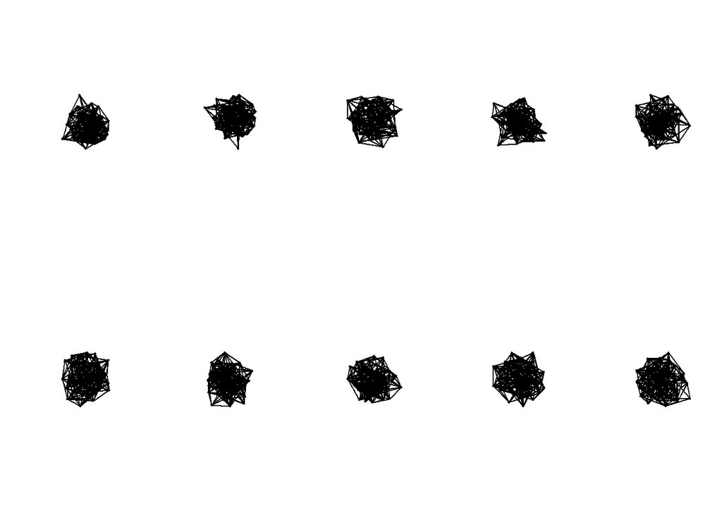

```r
#Simulate networks
sim_nets<-simulate(dirB3,nsim=10)

#Plot networks
par(mfrow=c(2,5))
for(i in 1:10){
  plot(sim_nets[[i]])
}
```

```r
par(mfrow=c(1,1))

#Convert to adjacency matrix (for the first simulated network only)
sim_net1<-as.matrix.network(sim_nets[[1]],attrname="weight")

sim_net1[1:10,1:10]
```

```
##    1 2 3 4 5 6 7 8 9 10
## 1  0 0 0 0 0 0 0 0 2  0
## 2  0 0 0 0 0 0 0 0 0  0
## 3  2 0 0 2 1 0 1 0 0  0
## 4  0 0 3 0 0 0 2 0 0  0
## 5  0 0 0 0 0 1 0 0 0  2
## 6  0 2 0 0 0 0 0 0 0  0
## 7  0 0 5 0 3 0 0 0 0  0
## 8  0 0 0 0 0 0 0 0 0  0
## 9  0 0 0 2 0 0 3 0 0  0
## 10 2 0 0 0 0 1 0 0 0  0
```

If there is time left in the session and you are interested then please feel free to try generating your own networks or using others from earlier in the session and get some more practice in fitting models or spend more time playing with simulating networks using ERGMs and seeing how they compare to the networks you started with.